Estadística Básica

[figure not shown]

# TP N° 4: Distribución de Probabilidades de Variables Aleatorias Continuas

# Ejercicios sugeridos

## Ejercicio 1

En un establecimiento lechero del Departamentos las Colonias se lleva registro de las producciones de leche. Éstos registros indican que la producción de leche por vaca por día sigue una distribución normal, promedio $\mu=25$ litros y con un desvío $\sigma=3$ litros.

**Responder:**

Si un día se decide visitar el establecimiento:

### Respuestas

**¿Cuál es la probabilidad de que la producción de ese día, sea de exactamente 25 litros?**

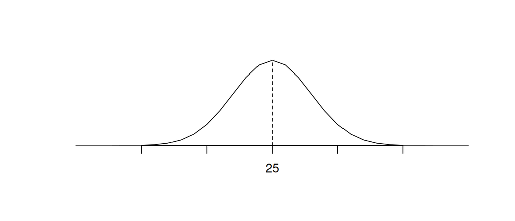

*Queremos calcular la probabilidad:* $P(x=25)$

La producción de leche es una variable continua y 25 litros es uno de los infinitos números que puede tomar por lo tanto su probabilidad es 0.

*NO utilizaremos la funcion `dnorm()` porque ésta función NO calcula propabilidad, sino que devuelve la densidad de probabilidad*

**¿Cuál es la probabilidad de que la producción de ese día, sea mayor a 20 litros?**

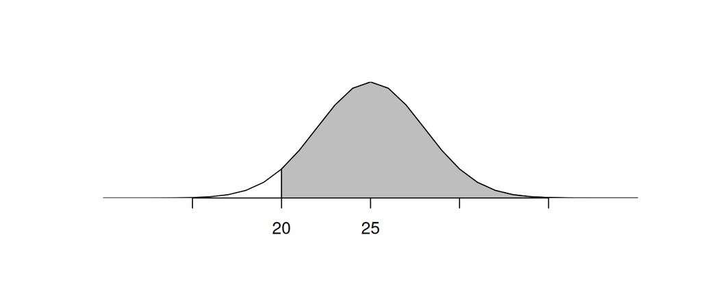

*Queremos calcular la probabilidad acumulada:* $P(x>20)$

*No importa si queremos incluir o no al 25 (recordar que la probabilidad en el punto es = 0, por lo tanto no cambia el resultado*

*Utilizaremos la funcion `pnorm()` porque queremos calcular la probabilidad acumulada*

Pasos:

**Paso 1:** definimos los parámetros de la distribución normal:

$\mu= 25$ litros, media de producción de leche

$\sigma= 3$ litros, desviación estándar de la producción de leche

```r
mu <- 25
sigma <- 3
```

**Paso 2:** otros argumentos que necesitaremos para usar la función:

Para definir `q`, no importa si lo queremos incluir o no, corresponde al valor de x incognita, en éste caso 20.

```r
q <- 20
```

**Paso 3:** Ingresamos todos los argumentos en la función:

```r
pnorm(q = q, mean = mu, sd = sigma, lower.tail = F)
```

```
[1] 0.9522096
```

Nos indica un valor de 0.9522096.

Expresado en porcentaje:

*Respuesta:* 95.22% es la probablidad de que la extracción de leche de ese día sea mayor a 20 litros por vaca.

**¿Cuál es la probablidad de que la producción de ese día, sea menor de 18 litros?**

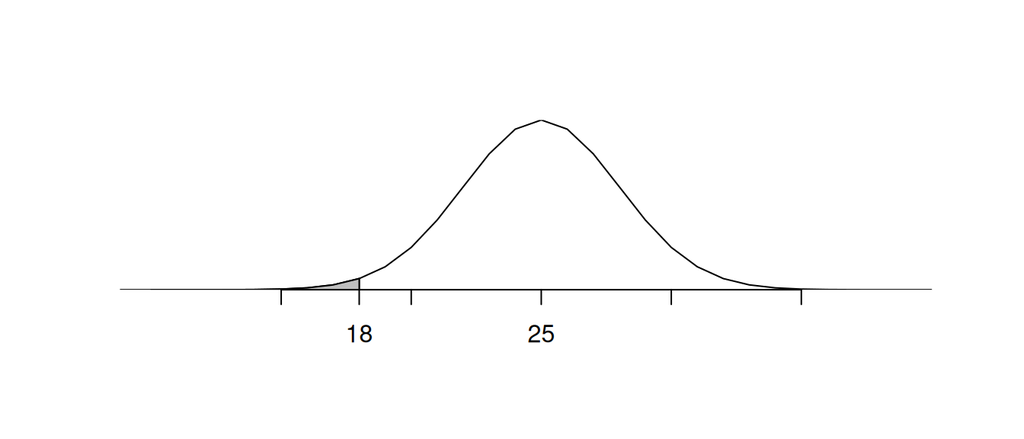

*Queremos calcular la probabilidad acumulada:* $P(x<18)$

*Utilizaremos la funcion `pnorm()` porque queremos calcular la probabilidad acumulada*

Pasos:

**Paso 1:** definimos los parámetros de la distribución normal:

$\mu= 25$ litros, media de producción de leche

$\sigma= 3$ litros, desviación estándar de la producción de leche

Ya los definimos antes:

```r
mu
```

```
[1] 25
```

```r
sigma
```

```
[1] 3
```

**Paso 2:** otros argumentos que necesitaremos para usar la función:

Para definir `q`, no importa si lo queremos incluir o no, corresponde al valor de x incognita, en éste caso 18

```r
q <- 18
```

**Paso 3:** Ingresamos todos los argumentos en la función:

```r
pnorm(q = q, mean = mu, sd = sigma)   # lower.tail = T por defecto
```

```
[1] 0.009815329
```

Nos indica un valor de 0.0098153.

Expresado en porcentaje:

*Respuesta:* 0.98% es la probablidad de que la extracción de leche de ese día sea menor a 18 litros por vaca.

**¿Cuál es la probablidad de que la producción de ese día, sea mayor de 20 litros y menor de 30 litros?**

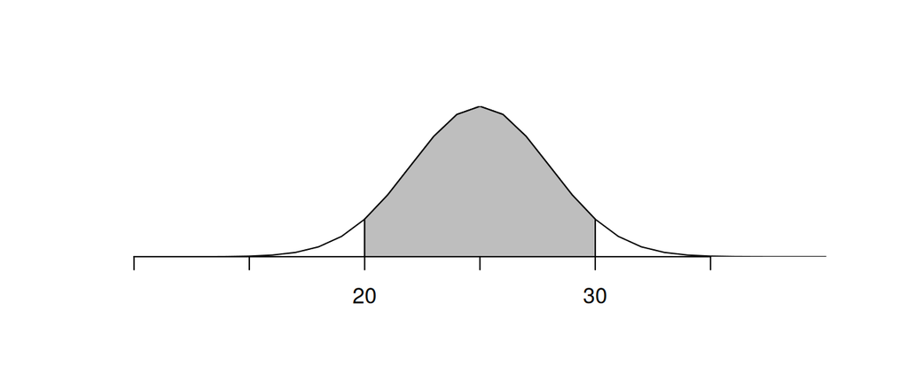

*Queremos calcular la probabilidad acumulada entre:* $P(20<x<30)$

*No importa si queremos incluir o no al 20 y al 30 (recordar que la probabilidad en el punto es = 0, por lo tanto no cambia el resultado*

*Utilizaremos la funcion `pnorm()` porque queremos calcular la probabilidad acumulada*

Pasos:

**Paso 1:** definimos los parámetros de la distribución normal:

$\mu= 25$ litros, media de producción de leche

$\sigma= 3$ litros, desviación estándar de la producción de leche

Ya los definimos antes:

```r
mu
```

```
[1] 25
```

```r
sigma
```

```
[1] 3
```

**Paso 2:** otros argumentos que necesitaremos para usar la función:

Para definir `q`, no importa si lo queremos incluir o no, corresponde al valor de x incognita, en éste caso 20 y 30.

```r
q1 <- 20
q2 <- 30
```

**Paso 3:** ingresamos todos los argumentos en la función, podemos hacerlo de 2 maneras:

Alternativa 1: restando probabilidades acumuladas, calculandolas por separado

```r
P_20 <- pnorm(q = q1, mean = mu, sd = sigma)   # lower.tail = T por defecto
P_30<- pnorm(q = q2, mean = mu, sd = sigma)   # lower.tail = T por defecto

P_30 - P_20           # valor mayor - menor
```

```
[1] 0.9044193
```

Alternativa 2: usando la función `diff()` para calcular diferencias (resta)

```r
diff(pnorm(q = c(q1,q2), mean = mu, sd = sigma))
```

```
[1] 0.9044193
```

```r
# en el vector q = c(q1, q2), primero el valor menor y luego el mayor
```

Nos indica un valor de 0.9044193.

Expresado en porcentaje:

*Respuesta:* 90.44% es la probablidad de que la extracción de leche de ese día esté entre 20 y 30 litros por vaca.

## Ejercicio 2

El peso de las mazorcas de maíz de una cierta variedad y bajo ciertas condiciones sigue una distribución normal con media de 350 g y desvío de 20 g.

1. Hallar la probabilidad de que elegida una planta al azar su peso esté entre 330 y 350 g.
2. Hallar la probabilidad de que sea mayor que 360 g.

### Respuestas

1. ```r
   # P(330<x<350)
   diff(pnorm(c(330, 350), 350, 20))
   ```

   ```
   [1] 0.3413447
   ```

2. ```r
   # P(x>360)
   pnorm(360, 350, 20, lower.tail = F)
   ```

   ```
   [1] 0.3085375
   ```

## Ejercicio 3

El diámetro de una cierta especie forestal, a los 10 años de vida, tiene una media de 40 cm y una variancia de 16 cm<sup>2</sup>.

1. ¿Qué porcentaje de ellos tendrá un diámetro menor de 34 cm?
2. ¿Qué porcentaje superarán los 48 cm?
3. ¿Qué porcentaje tendrán diámetros comprendidos entre 38 y 48 cm?
4. ¿Qué porcentaje tendrá diámetros entre 30 y 38 cm?

### Respuestas

1. ```r
   # P(x<34)
   pnorm(34, 40, sqrt(16)) * 100
   ```

   ```
   [1] 6.68072
   ```

2. ```r
   # P(x>48)
   pnorm(48, 40, sqrt(16), lower.tail = F) * 100
   ```

   ```
   [1] 2.275013
   ```

3. ```r
   # P(38<x<48)
   diff(pnorm(c(38, 48), 40, sqrt(16))) * 100
   ```

   ```
   [1] 66.87123
   ```

4. ```r
   # P(30<x<38)
   diff(pnorm(c(30, 38), 40, sqrt(16))) * 100
   ```

   ```
   [1] 30.23279
   ```

## Ejercicio 4

La capacidad para transportar vacunos en un camión de 30 m<sup>2</sup> de jaula es de 13200 kg, para 33 animales de 400 kg.

Los animales que entregará un productor para que ese camión jaula transporte, tienen una media $\mu=450$ kg con una desviación estándar de $\sigma=25$ kg cada uno.

**Responder:**

1. ¿Cuál es la probabilidad de que en una muestra de 20 animales, el peso promedio sea mayor a 460 kg?
2. ¿Cuál es la probabilidad de que en una muestra de 5 animales, el peso promedio sea menor a 430 kg?
3. ¿Cuál es la probabilidad de que en una muestra de 5 animales, el peso promedio sea mayor a 430 y menor a 450 kg?
4. ¿Cuál es la probabilidad de que en una muestra de 10 animales, el peso promedio sea exactamente 450 kg?

### Respuestas

**¿Cuál es la probabilidad de que en una muestra de 20 animales, el peso promedio sea mayor a 460 kg?**

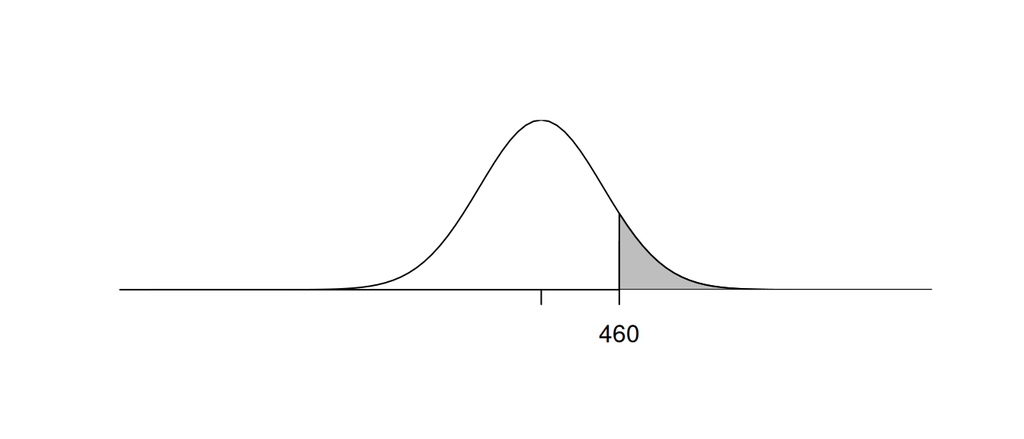

*Queremos calcular la probabilidad acumulada:* $P(\bar{X} > 460)$

*No importa si queremos incluir o no al 460 (recordar que la probabilidad en el punto es = 0, por lo tanto no cambia el resultado*

*Utilizaremos la funcion `pnorm()` porque queremos calcular la probabilidad acumulada*

Pasos:

**Paso 1:** definimos los parámetros de la distribución normal de la **media**:

$\mu_\bar{X} = \mu = 450$ kg, media de peso de los animales del establecimiento

$\sigma_\bar X = \frac{\sigma}{\sqrt n} = \frac{25}{\sqrt 20}$ litros, desviación estándar de la producción de leche para una muestra de 20 animales

```r
n<- 20   # animales de la muestra
mu_xbar <- 450
sigma_xbar <- 25/sqrt(n)
```

**Paso 2:** otros argumentos que necesitaremos para usar la función:

Para definir `q`, no importa si lo queremos incluir o no, corresponde al valor de x incognita, en éste caso 460.

```r
q <- 460
```

**Paso 3:** Ingresamos todos los argumentos en la función:

*`lower.tail = F` ya que queremos calcular valores mayores a 460*

```r
pnorm(q = q, mean = mu_xbar, sd = sigma_xbar, lower.tail = F)
```

```
[1] 0.03681914
```

Nos indica un valor de 0.0368191.

Expresado en porcentaje:

*Respuesta:* 3.68% es la probablidad de que en una muestra de 20 animales, el peso promedio sea mayor a 460 kg.

**¿Cuál es la probabilidad de que en una muestra de 5 animales, el peso promedio sea menor a 430 kg?**

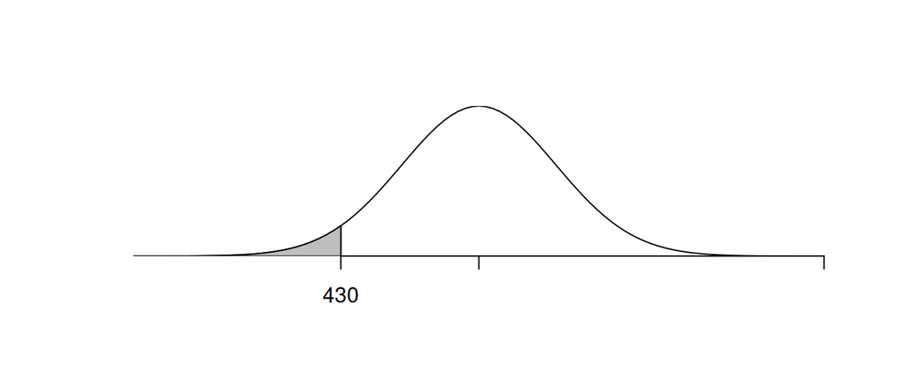

*Queremos calcular la probabilidad acumulada:* $P(\bar X < 430)$

*No importa si queremos incluir o no al 430 (recordar que la probabilidad en el punto es = 0, por lo tanto no cambia el resultado*

*Utilizaremos la funcion `pnorm()` porque queremos calcular la probabilidad acumulada*

Pasos:

**Paso 1:** definimos los parámetros de la distribución normal de la **media**:

$\mu_\bar X = 450$ kg, media de peso de los animales del establecimiento

$\sigma_\bar X = \frac{25}{\sqrt 5}$ litros, desviación estándar de la producción de leche para una muestra de 5 animales

```r
n<- 5   # animales de la muestra
mu_xbar <- 450
sigma_xbar <- 25/sqrt(n)
```

**Paso 2:** otros argumentos que necesitaremos para usar la función:

Para definir `q`, no importa si lo queremos incluir o no, corresponde al valor de x incognita, en éste caso 430.

```r
q <- 430
```

**Paso 3:** Ingresamos todos los argumentos en la función:

*`lower.tail = T` por defecto, queremos calcular valores menores a 430*

```r
pnorm(q = q, mean = mu_xbar, sd = sigma_xbar)    # lower.tail = T, por defecto
```

```
[1] 0.03681914
```

Nos indica un valor de 0.0368191.

Expresado en porcentaje:

*Respuesta:* 3.68% es la probablidad de que en una muestra de 5 animales, el peso promedio sea menor a 430 kg.

**¿Cuál es la probabilidad de que en una muestra de 5 animales, el peso promedio sea mayor a 430 y menor a 450 kg?**

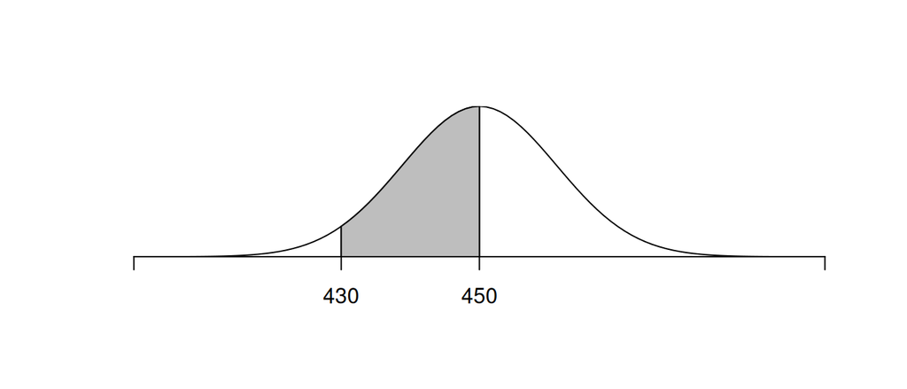

*Queremos calcular la probabilidad acumulada:* $P(430< \bar X <450)$

*No importa si queremos incluir o no al 430 y 450 (recordar que la probabilidad en el punto es = 0, por lo tanto no cambia el resultado*

*Utilizaremos la funcion `pnorm()` porque queremos calcular la probabilidad acumulada*

Pasos:

**Paso 1:** definimos los parámetros de la distribución normal de la **media**:

$\mu_\bar X= 450$ kg, media de peso de los animales del establecimiento

$\sigma_\bar X= \frac{25}{\sqrt 5}$ litros, desviación estándar de la producción de leche para una muestra de 5 animales

```r
n<- 5   # animales de la muestra
mu_xbar <- 450
sigma_xbar <- 25/sqrt(n)
```

**Paso 2:** otros argumentos que necesitaremos para usar la función:

```r
q1 <- 430
q2 <- 450
```

**Paso 3:** ingresamos todos los argumentos en la función, podemos hacerlo de 2 maneras:

Alternativa 1: restando probabilidades acumuladas, calculandolas por separado

```r
P_430 <- pnorm(q = q1, mean = mu_xbar, sd = sigma_xbar)   # lower.tail = T por defecto
P_450<- pnorm(q = q2, mean = mu_xbar, sd = sigma_xbar)   # lower.tail = T por defecto

P_450 - P_430           # valor mayor - menor
```

```
[1] 0.4631809
```

Alternativa 2: usando la función `diff()` para calcular diferencias (resta)

```r
diff(pnorm(q = c(q1,q2), mean = mu_xbar, sd = sigma_xbar))
```

```
[1] 0.4631809
```

```r
# en el vector q = c(q1, q2), primero el valor menor y luego el mayor
```

Nos indica un valor de 0.4631809.

Expresado en porcentaje:

*Respuesta:* 46.32% es la probablidad de que en una muestra de 5 animales, el peso promedio esté entre 430 y 450 kg.

**¿Cuál es la probabilidad de que en una muestra de 10 animales, el peso promedio sea exactamente 450 kg?**

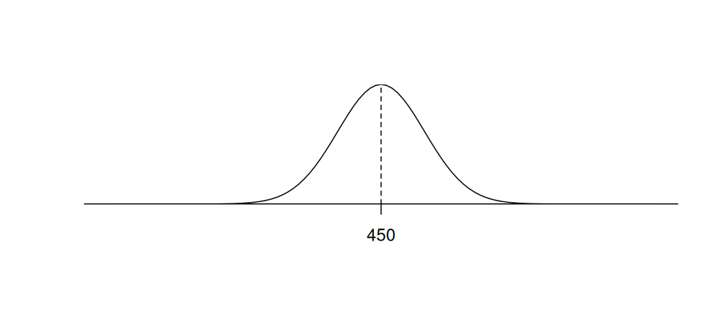

*Queremos calcular la probabilidad:* $P(\bar{X} = 450)$

Los kg de peso de un animal es una variable continua y 450 kg es uno de los infinitos números que puede tomar por lo tanto su probabilidad es 0.

## Ejercicio 5

En una plantación forestal los DAP (diámetro a la altura del pecho, en cm) de los arboles de Eucalyptus grandis de 10 años de edad, siguen una distribución normal con un diámetro medio de $\mu$ = 25 cm y una desvío de $\sigma$ = 5.5 cm. Determinar:

1. En una muestra de 15 arboles, ¿cuál es el numero esperado de DAP?
2. ¿Cuál es la probabilidad de que en un muestra de 3 árboles, el DAP sea menor a 20 cm?
3. ¿Cuál es la probabilidad de que en un muestra de 10 árboles, el DAP sea mayor o igual a 20 cm?
4. ¿Cuál es la probabilidad de que en un muestra de 5 árboles, el DAP sea menor a 35 cm o mayor a 15 cm?
5. ¿Cuál es la probabilidad de que en un muestra de 5 árboles, el DAP sea menor o igual a 15 cm o mayor a 30 cm?

### Respuestas

Datos:

```r
mu <- 25
sigma <- 5.5
```

El número esperado de DAP es 25 cm.

```r
q <- 20
n <- 3
pnorm(q = q, mean = mu, sd = sigma/sqrt(n))
```

```
[1] 0.05767537
```

*Respuesta:* 5.77% es la probablidad de que en un muestra de 3 árboles, el DAP sea menor a 20 cm.

```r
q <- 20
n <- 10
pnorm(q = q, mean = mu, sd = sigma/sqrt(n), lower.tail = F)
```

```
[1] 0.9979786
```

*Respuesta:* 99.8% es la probablidad de que en un muestra de 10 árboles, el DAP sea mayor o igual a 20 cm.

```r
q1 <- 15
q2 <- 35
n <- 5
diff(pnorm(q = c(q1, q2), mean = mu, sd = sigma/sqrt(n)))
```

```
[1] 0.9999521
```

*Respuesta:* 100% es la probablidad de que en un muestra de 5 árboles, el DAP sea menor a 35 cm o mayor a 15 cm.

```r
q1 <- 15
q2 <- 30
n <- 5
pnorm(q = q1, mean = mu, sd = sigma/sqrt(n)) + pnorm(q = q2, mean = mu, sd = sigma/sqrt(n), lower.tail = F)
```

```
[1] 0.02106088
```

## Ejercicio 6

Supóngase que la longitud del pétalo de una población de plantas de la especie X se distribuye normalmente con $\mu = 3.2$ cm y $\sigma = 1.8$ cm.

1. ¿Cuál es la probabilidad de obtener un pétalo de longitud mayor que 4,5 cm?
2. ¿Cuál es la probabilidad de obtener un pétalo de longitud mayor que 1,78 cm?
3. ¿Cuál es la probabilidad de obtener un pétalo de longitud entre 2,9 y 3,6 cm?
4. ¿Cuál es la probabilidad de que en una muestra de 5 pétalos la longitud de sea mayor que 4,5 cm?
5. ¿Cuál es la probabilidad de que en una muestra de 3 pétalos la longitud de sea menor que 1,78 cm?
6. ¿Cuál es la probabilidad de que en una muestra de 5 pétalos la longitud sea entre 2,9 y 3,6 cm?

### Respuestas

1. ```r
   # P(x>4.5)
   pnorm(q = 4.5, mean = 3.2, sd = 1.8, lower.tail = F)
   ```

   ```
   [1] 0.2350789
   ```

2. ```r
   # P(x>1.78)
   pnorm(q = 1.78, mean = 3.2, sd = 1.8, lower.tail = F)
   ```

   ```
   [1] 0.7849115
   ```

3. ```r
   # P(2.9<x<3.6)
   diff(pnorm(q = c(2.9, 3.6), mean = 3.2, sd = 1.8))
   ```

   ```
   [1] 0.1541134
   ```

4. ```r
   # P(x>4.5)
   pnorm(q = 4.5, mean = 3.2, sd = 1.8/sqrt(5), lower.tail = F)
   ```

   ```
   [1] 0.05316206
   ```

5. ```r
   # P(x>1.78)
   pnorm(q = 1.78, mean = 3.2, sd = 1.8/sqrt(3), lower.tail = F)
   ```

   ```
   [1] 0.9140926
   ```

6. ```r
   # P(2.9<x<3.6)
   diff(pnorm(q = c(2.9, 3.6), mean = 3.2, sd = 1.8/sqrt(5)))
   ```

   ```
   [1] 0.3356776
   ```

# Ejercicios complementarios

## Ejercicio 7

En una distribución normal con $\mu$ = 50 y $\sigma$ = 8, determinar:

1. $P(X \le 60)$
2. $P(X > 55)$
3. $P(45 \le X \le 52)$
4. ¿Cúal es el valor de la variable que deja por encima el 10% de las observaciones?

### Respuestas

1. ```r
   # P(X≤60)
   pnorm(q = 60, mean = 50, sd = 8)
   ```

   ```
   [1] 0.8943502
   ```

2. ```r
   # P(X>55)
   pnorm(q = 55, mean = 50, sd = 8, lower.tail = F)
   ```

   ```
   [1] 0.2659855
   ```

3. ```r
   # P(45≤X≤52)
   diff(pnorm(q = c(45, 52), mean = 50, sd = 8))
   ```

   ```
   [1] 0.3327208
   ```

   ```
   [1] 61.53396
   ```

## Ejercicio 8

Sea X una variable con una distribución normal $N(0,1)$ hallar:

1. $P(0 \le X \le 1.5)$
2. $P(-0.58 \le X \le 0)$

### Respuestas

1. ```r
   # P(0≤X≤1.5)
   diff(pnorm(q = c(0, 1.5)))
   ```

   ```
   [1] 0.4331928
   ```

2. ```r
   # P(-0.58≤X≤0)
   diff(pnorm(q = c(-0.58, 0)))
   ```

   ```
   [1] 0.2190427
   ```

## Ejercicio 9

Hallar el área bajo la curva normal:

1. A la izquierda de $Z = 1.78$
2. A la izquierda de $Z = 0.56$
3. A la derecha de $Z = -1.45$
4. $Z \pm 2.16$
5. Entre -0.80 y 1.53
6. A la izquierda de $Z = -2.52$ y a la derecha de $Z = 1.83$

### Respuestas

1. ```r
   pnorm(q = 1.78)
   ```

   ```
   [1] 0.962462
   ```

2. ```r
   pnorm(q = 0.56)
   ```

   ```
   [1] 0.7122603
   ```

3. ```r
   pnorm(q = -1.45, lower.tail = F)
   ```

   ```
   [1] 0.9264707
   ```

4. ```r
   diff(pnorm(q = c(-2.16, 2.16)))
   ```

   ```
   [1] 0.9692273
   ```

5. ```r
   diff(pnorm(q = c(-0.8, 1.53)))
   ```

   ```
   [1] 0.7251362
   ```

6. ```r
   pnorm(q = -2.52) + pnorm(q = 1.83, lower.tail = F)
   ```

   ```
   [1] 0.03949271
   ```

## Ejercicio 10

El peso de niños chinos recién nacidos, tiene una media de 109,9 onzas y una desviación típica de 13,593 onzas. Al extraer una muestra al azar de actas de nacimiento de esa población. ¿Cuál es la probabilidad de obtener un niño con un peso de 151 onzas o superior?

### Respuestas

```r
pnorm(q = 151, mean = 109.9, sd = 13.593, lower.tail = F)
```

```
[1] 0.00124887
```

## Ejercicio 11

La longitud promedio del tiempo que un cliente debe esperar para ser atendido por un empleado del negocio es de 3.3 minutos y el desvío estándar de 2.6 minutos. Se observa en este negocio una muestra al azar de 100 clientes. Se calcula la longitud media del tiempo que los mismos deben esperar para ser atendidos por un empleado.

1. ¿Cuáles son los valores de $\mu$ y $\sigma$? ¿Qué parámetros poblacionales describen?.
2. ¿Cuál es la forma de la distribución muestral de la longitud media del tiempo que tienen que esperar los 100 clientes para ser atendidos? ¿Por que?
3. Calcule $\mu_\bar{X}$ y $\sigma_\bar{X}$

### Respuestas

1. $\mu$ = 3.3 minutos y $\sigma$ = 2.6 minutos.
2. $\bar{X} \sim N(3.3, \dfrac{2.6}{\sqrt{100}}$
3. $\mu_\bar{X}$ = 3.3 y $\sigma_\bar{X}$ = 0.26

## Ejercicio 12

La distribución de los salarios de 2000 trabajadores tiene una media de $500 y un desvío de $45. Supóngase que la distribución es normal:

1. ¿Cuántos ganan $ 550 o menos?
2. ¿Cuántos trabajadores ganan $600 ó más?
3. ¿Cuantos trabajadores ganan entre $450 y $620?

### Respuestas

1. ```r
   # P(x<=550)
   round(2000 * pnorm(550, 500, 45))
   ```

   ```
   [1] 1733
   ```

2. ```r
   # P(x>600)
   round(2000 * pnorm(600, 500, 45, lower.tail = F))
   ```

   ```
   [1] 26
   ```

3. ```r
   # P(450<x<620)
   round(2000 * diff(pnorm(c(450, 620), 500, 45)))
   ```

   ```
   [1] 1726
   ```

## Ejercicio 13

Se supone que la altura de los jóvenes tiene una distribución normal con $\mu = 170$ cm y $\sigma = 5$ cm. Hallar la probabilidad de que elegido un joven al azar su altura sea superior a los 175 cm.

### Respuestas

```r
# P(x>175)
pnorm(175, 170, 5, lower.tail = F)
```

```
[1] 0.1586553
```

## Ejercicio 14

Se somete a prueba cierta marca de neumáticos y se comprueba que su duración tiene una distribución normal cuya media es de 23500 km y su desvío de 3000 km. ¿Cuál es la esperanza en cuanto al número de neumáticos que duren mas de 25000 km en una producción de 2000 neumáticos?

### Respuestas

```r
round(2000 * pnorm(25000, 23500, 3000, lower.tail = F))
```

```
[1] 617
```

## Ejercicio 15

La nota media en un examen es 72 y la desviación típica 9. Si el 10% del curso recibirá grado A, ¿cuál es la nota mínima para aprobar?

### Respuestas

```r
qnorm(p = 0.1, 72, 9, lower.tail = F)
```

```
[1] 83.53396
```

## Ejercicio 16

Si un conjunto de medidas está normalmente distribuida, ¿qué porcentaje de ellas difiere de la media:

1. más o menos de 0,5 desviaciones típicas?
2. más o menos de 0,75 desviaciones típicas?

### Respuestas

1. ```r
   diff(pnorm(c(-0.5, 0.5))) * 100
   ```

   ```
   [1] 38.29249
   ```

2. ```r
   diff(pnorm(c(-0.75, 0.75))) * 100
   ```

   ```
   [1] 54.67453
   ```

## Ejercicio 17

Si las alturas de 300 estudiantes están normalmente distribuidas con media 1.68 m y desviación típica 0.20 m, ¿cuántos estudiantes tienen altura:

1. mayor de 1,72 m?
2. menor que 1,64 m?
3. entre 1,65 y 1,72 m?

### Respuestas

1. ```r
   # P(x>1.72)
   round(300 * pnorm(1.72, 1.68, 0.2, lower.tail = F))
   ```

   ```
   [1] 126
   ```

2. ```r
   # P(x<1.64)
   round(300 * pnorm(1.64, 1.68, 0.2))
   ```

   ```
   [1] 126
   ```

3. ```r
   # P(1.65<x<1.72)
   round(300 * diff(pnorm(c(1.65, 1.72), 1.68, 0.2)))
   ```

   ```
   [1] 42
   ```

## Ejercicio 18

Mediante la aproximación normal a la distribución binomial hallar la probabilidad de que en 200 lanzamientos de una moneda haya:

1. entre 80 y 120 caras inclusive
2. menos de 90 caras
3. menos de 85 o más de 115 caras
4. 100 caras exactamente.
5. Calcule las probabilidades de los items anteriores mediante la distribución original (binomial) y compárelos con los obtenidos mediante la aproximación.

### Respuestas

1. ```r
   # P(80 <= x <= 120)
   mu <- 200 * 0.5
   sigma <- sqrt(200*0.5**2)
   diff(pnorm(c(80-0.5, 120+0.5), mu, sigma))
   ```

   ```
   [1] 0.9962581
   ```

2. ```r
   # P(x<90)
   pnorm(90-0.5, mu, sigma)
   ```

   ```
   [1] 0.06878195
   ```

3. ```r
   # P(85>x>115)
   pnorm(85-0.5, mu, sigma) + pnorm(115+0.5, mu, sigma, lower.tail = F)
   ```

   ```
   [1] 0.02837727
   ```

4. ```r
   # P(x=100)
   diff(pnorm(c(100 - 0.5, 100 + 0.5), mu, sigma))
   ```

   ```
   [1] 0.05637198
   ```

5. ```r
   # Item a
   diff(pbinom(c(80, 120), 200, 0.5))
   ```

   ```
   [1] 0.9953399
   ```

   ```r
   # Item b
   pbinom(89, 200, 0.5)
   ```

   ```
   [1] 0.06868333
   ```

   ```r
   # Item c
   pbinom(84, 200, 0.5) + pbinom(115, 200, 0.5, lower.tail = F)
   ```

   ```
   [1] 0.02812541
   ```

   ```r
   # Item d
   dbinom(100, 200, 0.5)
   ```

   ```
   [1] 0.05634848
   ```

## Ejercicio 19

El 10% de las piezas producidas en una máquina son defectuosas. Mediante la aproximación normal a la distribución binomial hallar la probabilidad de que en una muestra aleatoria de 400 piezas sean defectuosas:

1. a lo sumo 30
2. entre 30 y 50
3. entre 35 y 45
4. 55 o más.
5. Calcule las probabilidades de los items anteriores mediante la distribución original (binomial) y compárelos con los obtenidos mediante la aproximación.

### Respuestas

1. ```r
   mu <- 400 * 0.1
   sigma <- sqrt(400 * 0.1 * 0.9)

   # P(x<=30)
   pnorm(30+0.5, mu, sigma)
   ```

   ```
   [1] 0.05667275
   ```

2. ```r
   # P(30<x<50)
   diff(pnorm(c(30-0.5, 50+0.5), mu, sigma))
   ```

   ```
   [1] 0.9198817
   ```

3. ```r
   # P(35<x<45)
   diff(pnorm(c(35-0.5, 45+0.5), mu, sigma))
   ```

   ```
   [1] 0.6406827
   ```

4. ```r
   # P(x>=55)
   pnorm(55-0.5, mu, sigma, lower.tail = F)
   ```

   ```
   [1] 0.007831677
   ```

5. ```r
   # item a
   pbinom(30, 400, 0.1)
   ```

   ```
   [1] 0.05239125
   ```

   ```r
   # item b
   diff(pbinom(c(30, 50), 400, 0.1))
   ```

   ```
   [1] 0.9039643
   ```

   ```r
   # item c
   diff(pbinom(c(35, 45), 400, 0.1))
   ```

   ```
   [1] 0.5918347
   ```

   ```r
   # item d
   pbinom(54, 400, 0.1, lower.tail = F)
   ```

   ```
   [1] 0.0100439
   ```

## Ejercicio 20

El número de partículas contaminantes en un cm<sup>3</sup> de agua de una laguna, tiene una distribución de Poisson con media igual a 900. ¿Cuál es la probabilidad, al analizar un cm3 de agua extraído al azar de dicha laguna, de encontrar menos de 850 partículas?

Realice los cálculos utilizando la aproximación normal a la distribución de Poisson y compárelos con los obtenidos con la distribución Poisson.

### Respuestas

```r
# Aproximación
mu <- 900
sigma <- sqrt(900)
pnorm(850-0.5, mu, sigma)
```

```
[1] 0.04615529
```

```r
# Poisson
ppois(849, lambda = 900)
```

```
[1] 0.04514728
```

## Ejercicio 21

En comercio de ventas de insumos agropecuarios, en promedio ingresan 1 cliente cada 5 minutos entre las 10 hs y las 12 hs. ¿Cuál es la probabilidad de que ingresen mas de 17 clientes entre las 10 hs y las 11 hs?

Realice los cálculos utilizando la aproximación normal a la distribución de Poisson y compárelos con los obtenidos con la distribución Poisson.

### Respuestas

```r
# Aproximación
mu <- 1/5 * 60
sigma <- sqrt(1/5 * 60)
pnorm(17+0.5, mu, sigma, lower.tail = F)
```

```
[1] 0.0561756
```

```r
# Poisson
ppois(17, lambda = mu, lower.tail = F)
```

```
[1] 0.0629663
```

## Ejercicio 22

La distribución del número de caracteres impresos por segundo por una clase particular de impresora de línea en una terminal de computadora tiene los siguientes parámetros $\mu = 45$ caracteres por segundo y $\sigma^2 = 4$ (caracteres seg<sup>-1</sup>)<sup>2</sup>.

1. Describa la distribución muestral del número medio de caracteres impresos por segundo para muestras aleatorias de 60 segundos.
2. Encontrar la probabilidad de que la media de la muestra, para una muestra al azar de 60 segundos, esté entre 44,5 y 45,3 caracteres por segundo.
3. Encontrar la probabilidad de que la media de la muestra sea menos de 44 caracteres por segundo.

### Respuestas

1. $\bar{X} \sim N \left(45, \dfrac{2}{\sqrt{60}} \right)$

2. ```r
   diff(pnorm(c(44.5, 45.3), mean = 45, sd = 2/sqrt(60)))
   ```

   ```
   [1] 0.8509572
   ```

3. ```r
   pnorm(44, mean = 45, sd = 2/sqrt(60))
   ```

   ```
   [1] 5.375559e-05
   ```

## Ejercicio 23

La distribución del número de bollos de panes vendidos en una gran panadería en los últimos 5 años tiene una media de 250 bollos y una variancia de 2025 (bollos)<sup>2</sup>.

1. Describa la distribución muestral del número medio de bollos de pan vendidos en 50 días de venta, seleccionados al azar.
2. Calcule la probabilidad de que el número medio de bollos vendidos en 50 días esté entre 240 y 250.
3. Calcule la probabilidad de que la media sea mayor de 265 bollos.

### Respuestas

1. $\bar{X} \sim N \left( 250, \sqrt{\dfrac{2025}{50}} \right)$

2. ```r
   diff(pnorm(c(240, 250), mean = 250, sd = sqrt(2025/50)))
   ```

   ```
   [1] 0.4419491
   ```

3. ```r
   pnorm(265, mean = 250, sd = sqrt(2025/50), lower.tail = F)
   ```

   ```
   [1] 0.009211063
   ```

## Ejercicio 24

Una compañía manufacturera de envases informa que el número medio de roturas cada 8 horas en su máquina de línea de montaje es de 1.5. El desvío estándar del número de roturas es de 1.1. Una muestra al azar de 15 períodos de 8 horas es seleccionada y se registra el número de roturas. Luego se calcula la media de la muestra.

1. ¿Cuál es la población original de este problema?
2. ¿Cuál es la media y el desvío estándar de esta población?
3. ¿Cuáles son las medias y el error estándar de la distribución muestral de $\bar{X}$?.
4. ¿Será la distribución de $\bar{X}$ aproximadamente normal? Explique.

### Respuestas

1. La población es el número de roturas cada 8 horas.
2. $\mu = 1.5$ roturas y $\sigma = 1.1$ roturas
3. $\mu_\bar{X} = 1.5$ roturas y $\sigma_\bar{X} = \dfrac{1.1}{\sqrt{15}}$ roturas
4. Si, por el Teorema del Límite Central.

[por [Agustín Alesso y Patricia Acetta](https://github.com/Estadistica-FCA) (2026) está bajo una Licencia Creative Commons Atribución-NoComercial-SinDerivadas 4.0 Internacional.](https://creativecommons.org/licenses/by-nc-nd/4.0/)